# Behaviour Duration Report

2025-02-12

# Behaviour Classification of Individuals

## Using this report to generate features:

Window lengths are used to condense multiple observations into a single row of data.

## Visualising your data before processing:

One of the more important and overlooked steps of processing data is visualising it for the purposes of determining if your behaviours are internally consistent compared to themselves and other behaviours.

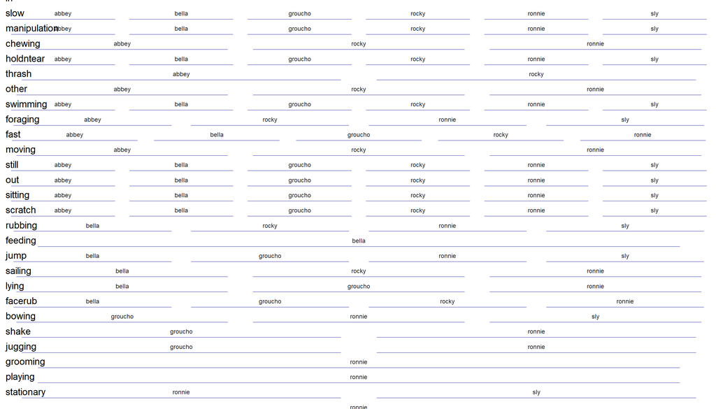

### Features:

Generating features is a process of taking variables within multiple rows of a dataframe and generating additional variables in a long column for use in statistical analysis. To generate time and statistical features within accelerometer data we require:

- The sample rate of the accelerometer (in seconds) used in the study
- The overlap percentage of our windows.
- The window length (in seconds).

### Windows:

Within timeseries data, windows are segments of the dataset that are used to generate rolling statistics.

#### Overlap Percentage:

The overlap percentage determines how much of the windows overlap. This can be beneficial for minimising the risk that behaviours are missed by a window length being placed between two behaviours. Increasing window overlap percentage will increase how many total windows are produced, this can increase how many data points you can analyse but also increases the computing time and power necessary to generate features, particularly within large datasets. Some studies (cite) indicate that little value is to be gained from increasing your overlap percentage above 50%.  
If you are unsure, set your overlap percentage to 50%.

#### Window Length:

Larger window lengths can increase your chance of capturing multiple behaviours within a single feature. Shorter lengths decrease your chances of capturing entire behaviours. As a general rule, you should set your window length to be the same as the smallest of your all behaviours lower-quantiles. You may however want to select based on the the smallest median behaviour duration instead. This will ensure your likelihood of capturing the entirety of a single behaviour and it not being confused with another.  
For example, if you have three behaviours named: Jumping, Turning and Sitting, with lower quantile duration in seconds of: 2, 4 and 30 respectfully, you would be best to select a window length of two seconds, based on the duration of Jumping. However you may want to base your window length off of your shortest median behaviour length instead for example. The plot and tables below include information on all of these numbers to help you make this decision.

## Behaviour Duration by Activity

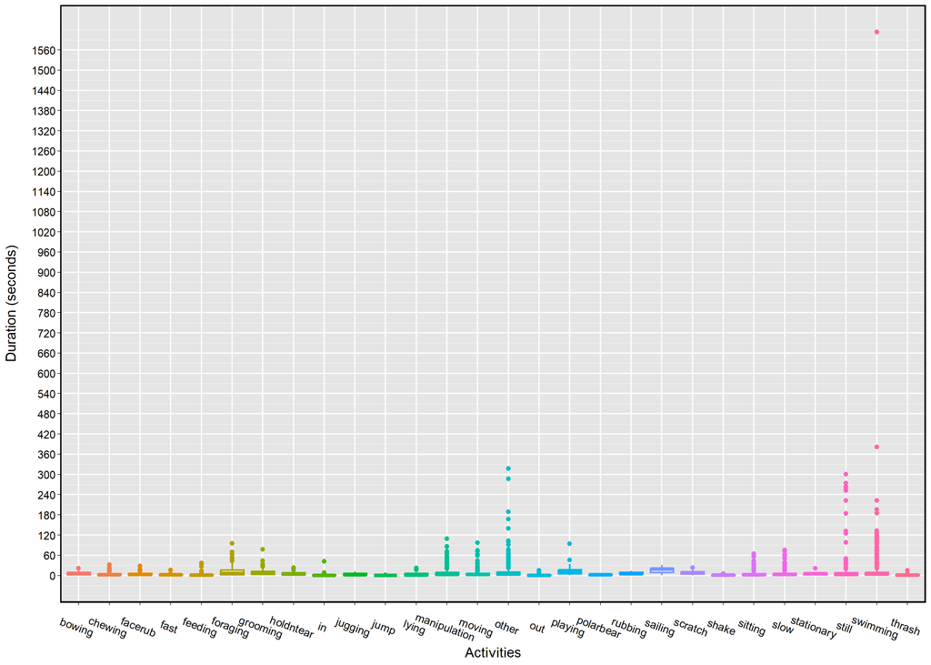

| Behaviour | Mean | Minimum | Median | Maximum | Lower Quantile |
| --- | --- | --- | --- | --- | --- |
| bowing | 7.162609 | 0.80 | 5.10 | 21.52 | 2.34 |
| chewing | 3.888479 | 0.40 | 2.36 | 31.84 | 1.24 |
| facerub | 5.770400 | 0.92 | 3.36 | 28.64 | 2.69 |
| fast | 2.831724 | 0.36 | 2.36 | 16.08 | 2.01 |
| feeding | 2.689036 | 0.24 | 1.16 | 37.20 | 0.68 |
| foraging | 12.236889 | 0.44 | 6.94 | 95.52 | 3.02 |
| grooming | 10.396863 | 0.68 | 6.88 | 78.00 | 3.83 |
| holdntear | 6.062222 | 0.36 | 4.92 | 22.96 | 2.44 |
| in | 1.509610 | 0.24 | 0.96 | 42.48 | 0.54 |
| jugging | 4.330526 | 0.72 | 2.84 | 11.28 | 1.78 |
| jump | 1.031111 | 0.72 | 1.00 | 1.76 | 0.84 |
| lying | 5.570667 | 0.40 | 2.04 | 22.00 | 1.02 |
| manipulation | 8.548112 | 0.24 | 3.80 | 109.64 | 1.68 |
| moving | 6.023680 | 0.24 | 3.28 | 97.76 | 1.60 |
| other | 11.409157 | 0.12 | 4.72 | 317.72 | 2.24 |
| out | 1.035278 | 0.04 | 0.76 | 15.00 | 0.52 |
| playing | 17.560000 | 1.48 | 10.88 | 94.16 | 5.38 |
| polarbear | 2.424000 | 1.00 | 2.36 | 4.28 | 1.32 |
| rubbing | 6.866667 | 2.24 | 5.44 | 13.80 | 5.04 |
| sailing | 16.086316 | 1.08 | 18.96 | 31.36 | 9.74 |
| scratch | 8.542963 | 1.04 | 8.48 | 23.32 | 4.26 |
| shake | 1.365000 | 0.44 | 1.26 | 5.68 | 0.84 |
| sitting | 5.146407 | 0.08 | 2.56 | 65.08 | 1.20 |
| slow | 5.805989 | 0.32 | 3.72 | 75.96 | 1.80 |
| stationary | 7.106667 | 2.20 | 5.06 | 21.20 | 2.93 |
| still | 18.221991 | 0.20 | 3.24 | 301.12 | 1.46 |
| swimming | 13.768503 | 0.36 | 4.12 | 1612.88 | 2.28 |
| thrash | 1.665455 | 0.28 | 1.16 | 14.92 | 0.76 |

### Summary

#### Minimum Behaviour Duration:

Your behaviour(s) with the shortest minimum duration are:  
**out** with a duration of: 0.04 seconds

#### Median Behaviour Duration:

Your behaviour(s) with the shortest median duration are:  
**out** with a duration of: 0.76 seconds

#### Lower-Quantile Behaviour Duration:

Your behaviour(s) with the smallest lower quantiles are:  
**out** with a duration of: 0.52 seconds

#### Recommendations:

Based on the **Ladds_Seal** dataset, it is recommended that you set your window length to be either:

- **0.52 seconds** based on your shortest lower quartile behaviour durations
- **0.76 seconds** based on your shortest median behaviour durations